# Analysis of Maryland Statewide Vehicle Crashes

#### by Stephen Duffy

In this tutorial I will go through and analyze vehicle crashes in maryland statewide and see if there are any interesting patterns. I will also investigate how road conditions affect crash numbers as that has always been interesting to me, ie seeing how wet or icy roads increases the number of crashes.

## Getting Started

First off, we need to import the libraries we will be using to analyze our data.

```python
import pandas as pd
import numpy as np
import matplotlib.pyplot as plt
import statistics
import math
import scipy.stats
import warnings
from datetime import datetime

# there was some annoying warning and I want to get rid of it
warnings.simplefilter(action='ignore')
```

The data we will be processing can either be accessed directly using a URL or downloaded and used locally. Regardless of how it is aquired, we will be importing the data as a CSV as it is easy to convert into a pandas dataframe, which we will be using a lot in this tutorial, and it is a fairly common format. Since we are using pandas to hold and analyze our data we can simply call 'read_csv' from the pandas library and either provide it a string of a local path to the downloaded data or provide the URL link provided by the data owner, like we do below. The data is a little large to download so in this case we will be using a URL to grab the data.

## Reading and Curating the Data

This particular dataset is fairly large with over 771K rows, this makes it a little hard to process just due to its sheer size. We dont really want to wait minutes for the data to process and since we are graphing, too many points could clutter our graph and make it hard to interpret. For these reasons we are going to be cutting it down to only 100,000 rows which still gives us a lot of room to work with. If importing data via URL like below and if the source uses the Socrata Open Data API (SODA) like ours, by default SODA will only return 1000 rows. There are multiple ways to get aroud this but for this tutorial I just appended '?limit=100000' to the end of the url to get the 100,000 rows we need.

```python
# reading in directly from the site
crash_table_dirty = pd.read_csv("https://opendata.maryland.gov/resource/65du-s3qu.csv?$limit=100000", low_memory=False)

# look at the first 5 elements of the dataset
crash_table_dirty.head()
```

|  | year | quarter | light_desc | light_code | county_desc | county_no | muni_desc | muni_code | junction_desc | junction_code | ... | feet_miles_flag_desc | feet_miles_flag | distance_dir_flag | reference_no | reference_type_code | reference_suffix | reference_road_name | latitude | longitude | geocoded_column |
| --- | --- | --- | --- | --- | --- | --- | --- | --- | --- | --- | --- | --- | --- | --- | --- | --- | --- | --- | --- | --- | --- |
| 0 | 2020 | Q2 | Daylight | 1.00 | Baltimore | 3 | NaN | NaN | NaN | NaN | ... | NaN | NaN | NaN | NaN | NaN | NaN | NaN | 39.277263 | -76.503693 | POINT (-76.5036932 39.27726285) |
| 1 | 2020 | Q2 | NaN | 6.02 | Baltimore City | 24 | NaN | NaN | Non Intersection | 1.0 | ... | Miles | M | N | NaN | NaN | NaN | NORTH AVE | 39.311025 | -76.616429 | POINT (-76.616429453205 39.311024794431) |
| 2 | 2020 | Q2 | Daylight | 1.00 | Montgomery | 15 | NaN | NaN | NaN | NaN | ... | NaN | NaN | NaN | NaN | NaN | NaN | NaN | 39.140680 | -77.193413 | POINT (-77.193412729561 39.140680249069) |
| 3 | 2017 | Q2 | Daylight | 1.00 | Baltimore City | 24 | NaN | NaN | NaN | NaN | ... | NaN | NaN | NaN | NaN | NaN | NaN | NaN | 39.282928 | -76.635215 | POINT (-76.6352150952347 39.2829284750108) |
| 4 | 2020 | Q2 | Daylight | 1.00 | Cecil | 7 | NaN | NaN | NaN | NaN | ... | NaN | NaN | NaN | NaN | NaN | NaN | NaN | 39.611028 | -75.951314 | POINT (-75.951314 39.611027833333) |

5 rows × 56 columns

In the above dataset there are 56 columns. For our puropses which is an interest in the number of accidents and its relationship between weather and road conditions, most of these columns are not needed so they can be dropped to get a cleaner and easier to work with dataset. Many of the columns we are dropping end in '_code', which have a corrosponding column ending in '_desc' with the one ending in '_code' being the numeric representaion of the '_desc'. 'weather_desc' and 'weather_code' are an example of this. We might want some of the _code columns later but we are going to be dropping them for now since it is easier to understand the _desc better since it is in english.

```python
# grab only the columns we want
crash_table = crash_table_dirty[['surf_cond_desc', 'acc_date']]
crash_table.columns
```

[output not shown]

In the above dataset the only columns we care about are:

- road surface conditions
- accident date

Since we are looking to analyze accidents, lets first plot the number of collisions vs. date to see if there is any sort of trend. To do so we first need to rework how date is stored as it is currently just stored as an integer (eg. 20200518 is May 18th, 2020). We will do this by making a new column called 'date' to differentiate it from 'acc_date' which we currently have and convert 'acc_date' to a DateTime object that pandas can use to plot later on. Let's also cut off our data analysis at the end of 2020 since the dataset only goes a little bit into data for 2021. We are interested in how data behaves over all years so having a partial part of a year will likely skew the data so it is a good idea to just get rid of it.

```python
# make a new column called date and initialize it with nan's, which will be replaced with DateTime objects in the loop below
crash_table['date'] = pd.NA

# date is in a poor format so we will rework it
for index, row in crash_table.iterrows():
    # get the date in the current row
    old_date = str(row['acc_date'])

    # convert the date into DateTime
    new_date = pd.to_datetime(old_date, format='%Y%m%d', errors='ignore')

    # dont add stuff from 2021
    if new_date.year < 2021:
        # add the new date to the new 'date' column, replacing the nan that was there
        crash_table.at[index, 'date'] = new_date

# deletes any row from 2021
cutoff = pd.to_datetime("20210101", format='%Y%m%d', errors='ignore')
crash_table = crash_table[crash_table['date'] < cutoff]

# drops old date column that we are no longer using
crash_table_dirty.drop(['acc_date'], axis=1)
crash_table.head()
```

[output not shown]

Now that we have a proper, plottable, DateTime to use we can get into the nitty-gritty and start looking at our data more closely.

## Exploratory Data Analysis

### Plots

We will be using dictionaries to do many of our plots, and this code will near identical so lets just make a function since it is poor form to repeat code. Later in the code when using the functon, the height and width will be done on the fly and determined by me by how the graph looks. If you are looking to reproduce this or use this function yourself, playing with the height and width is neccecary.

```python
# plot a given dictionary as a scatter plot. Options for adding in polyfit line of specified degree, if 0 don't plot a polyfit line.
def plot_dict(dict_in, title, xlab, ylab, degree, height, width):
    # prepare to plot the dict
    lst = dict_in.items()
    lst = sorted(lst)

    # seperate the key's and value's into two seperate arrays corrosponding to x-axis and y-axis of plot
    x, y = zip(*lst)

    # plot it with labels and title
    plt.figure(figsize=(width, height))
    plt.title(title)
    plt.xlabel(xlab)
    plt.ylabel(ylab)
    plt.scatter(x, y)

    # optionally add a polyfit line if degree is greater than 0
    if degree > 0:
        poly_fit_model = np.poly1d(np.polyfit(x,y,degree))
        poly_line = np.linspace(x[0], x[-1], 50)
        plt.plot(poly_line, poly_fit_model(poly_line), color='red')
```

### Number of Accidents Over Time

The first thing I want to look at is how the number of accidents is distributed over time. That is, I want to plot the number of accidents vs. day to see if there are any interesting trends such as spikes during certain months, effects of the pandemic, if there is an increase in accidents over time or does it stay relatively the same, etc. I am not looking for anyting specific at this point, I'm just exploring the data.

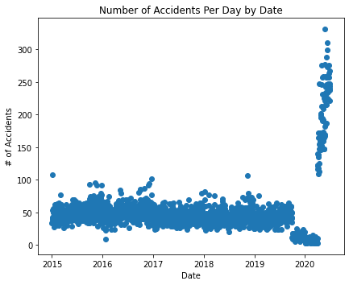

```python
# dictionary with date as key and number of accidents as value
acc_per_date = {}

# increment number of accidents if the date is already in the dict
for date in crash_table['date']:
    if date in acc_per_date:
        acc_per_date[date] += 1
    else:
        acc_per_date[date] = 1

# plot the dict using our plot function
plot_dict(acc_per_date, "Number of Accidents Per Day by Date", "Date", "# of Accidents", 0, 5.4, 6.8)
```

First lets look at the larger 2015-2020 block. We will use the same dictionary but only plot the data between our dates of interest, removing the 2020 spike from our plot. First lets plot the lower cluster.

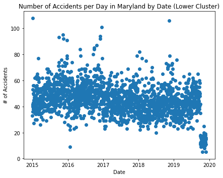

```python
# split the data into two dictionary by cluster
low_cluster = {}
high_cluster = {}

# pivot that splits the clusters (Jan 1, 2020), this was picked arbitrarily from looking at above plot
low_pivot = pd.to_datetime("20191130", format='%Y%m%d', errors='ignore')

# this pivot prevents the small data cluster from early 2021 from skewing the data.
high_pivot = pd.to_datetime("20210101", format='%Y%m%d', errors='ignore')

# break the dict down by date cluster
for key in acc_per_date:
    if key < low_pivot:
        low_cluster[key] = acc_per_date[key]
    elif key < high_pivot:
        high_cluster[key] = acc_per_date[key]

plot_dict(low_cluster, "Number of Accidents per Day in Maryland by Date (Lower Cluster)", "Date", "# of Accidents", 0, 5.4, 6.8)
```

Now that we are able to look a little closer at the lower cluster we can see that the number of accidents stays consistently within the same general range between around 20 to 70 accidents per day, with some scattered outliers where there were more accidents on a particular day. There is an interesting dip at the end of 2019 to the beginning of 2020 that we will need to look into later.

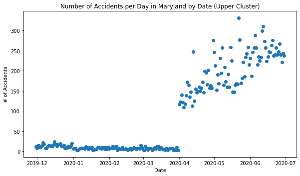

```python
plot_dict(high_cluster, "Number of Accidents per Day in Maryland by Date (Upper Cluster)", "Date", "# of Accidents", 0, 5.4, 9.8)
```

The higher cluster is even more interesting. With the scaling being changed to better show the upper cluster we can see how scattered it is. From a cursory look it almost appears to follow the shape of a sideways cone or horn getting wider as it gets closer to 2021. The lower end of the graph holds the same dip that we saw on the lower end cluster graph.

Given the strangeness of the 2020-present data, it is probably a good idea to set it aside and look for other trends in the 2015-2020 cluster as it appears to be more representative of "normal" accident data. We will return to the 2020-present data later on to see if information we learn about the 2015-2020 data correlates at all.

### Daily Averages

First thing I want to look at is the average number of accidents per day between 2015 and early 2020. Using the average per day might give us a better understanding of how accident numbers trend. It will also shrink our x axis down from 5 years to 1 year, which should give us a higher resolution on our data since there can only be 365 points vs the 100,000 we could have had before. One thing to not about the plot is that instead of being actual dates like 01/01/2020 in the above plots, since we are averaging the same day over multiple years it is easier to represent the x axis as "day of year" since they would be the same over multiple years. This is not as complicated as you might expect since the day of year is just an integer between 1 and 364 with january 1st being 1 and december 31st being 365. Also, since the spike in accidents in mid 2020 was odd considering the rest of the data, we will not consider it when calculating daily averages as it would clearly skew the data.

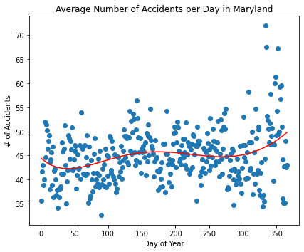

```python
monthly_avgs = {}

# look at lower cluster since upper cluster would skew the data
for date in low_cluster:
    new_date = date.dayofyear

    # add to running total of accident numbers and running total of elements that have been added
    if new_date in monthly_avgs:
        monthly_avgs[new_date][0] += low_cluster[date]
        monthly_avgs[new_date][1] += 1
    else:
        monthly_avgs[new_date] = [low_cluster[date],1] # first element in array is running total and second is number of units

# convert into avgs
for date in monthly_avgs:
    monthly_avgs[date] = monthly_avgs[date][0]/monthly_avgs[date][1]

# plot averages
plot_dict(monthly_avgs, "Average Number of Accidents per Day in Maryland", "Day of Year", "# of Accidents", 5, 5.4, 6.8)
```

Now that we have an idea of how the number of accidents look for a given year, lets investigate how road conditions affect accident numbers. First lets just plot the number of accidents for each road condition type. This is held in the 'surf_cond_desc' and 'surf_cond_code' columns. Lets look at the desc. one since it is more human readable. There are a number of rows that have 'nan' as their value for surface conditions. In order to include them and not just ignore them, we will consider them in the same category as 'Unknown' as 'Unknown' already exists as a category and the true surface contition for a nan entry is unknown to us.

```python
# surf cond count
surf_cond_counts = {}

# count number of accidents for each type of surface conditions
for index, row in crash_table.iterrows():
    # if the 'surf_cond_desc' is nan, consider it 'Unknown'
    condition = 'Unknown' if pd.isna(row['surf_cond_desc']) else row['surf_cond_desc']

    if condition in surf_cond_counts:
        surf_cond_counts[condition] += 1
    else:
        surf_cond_counts[condition] = 1
```

Now that we have tallied up the number of accidents for each road condition, lets plot it. Due to the length of the names of some of the conditions such as 'Mud, Dirt, Gravel' a normal bar plot will have the x axis cluttered and the names undreadable. For this reason we will plot it as a horizontal bar plot, which solves this issue.

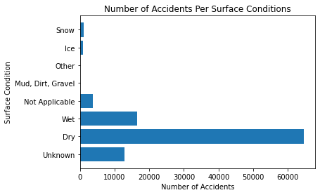

```python
y = np.arange(len(surf_cond_counts.keys()))
plt.title("Number of Accidents Per Surface Conditions")
plt.ylabel("Surface Condition")
plt.xlabel("Number of Accidents")
plt.barh(y, surf_cond_counts.values())
plt.yticks(y, surf_cond_counts.keys()); # adding the ';' here supresses a lot of annoying output and leaves just the plot
```

From the output of our plot, even when we add in the nan's as 'Unknown', the most common surface condition for accidents is by far 'Dry' interestingly enough. Originally I thought 'Wet' would be the most common as I always imagined that wet surfaces were more dangerous to drive on since they were more slippery. Given our data we can conclude this is obviously not the case.

Given the above plot was over all of our data, lets focus on the upper cluster spike in accidents from earlier that occured in early 2020 and see if there is a similar distribution for the surface conditions and number of accidents like in the plot above.

```python
# I chose this pivot by looking at the plot of the high cluster and beginning right when it starts to spike up
pivot = pd.to_datetime("20200415", format='%Y%m%d', errors='ignore')

spike_surf_cond_counts = {}

for index, row in crash_table.iterrows():
    if row['date'] > pivot:
        condition = 'Unknown' if pd.isna(row['surf_cond_desc']) else row['surf_cond_desc']
        if condition in spike_surf_cond_counts:
            spike_surf_cond_counts[condition] += 1
        else:
            spike_surf_cond_counts[condition] = 1
```

Now that we have counted, let's plot it.

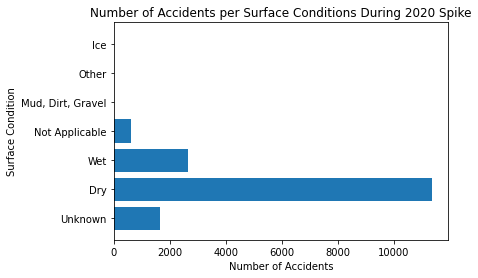

```python
y = np.arange(len(spike_surf_cond_counts.keys()))
plt.title("Number of Accidents per Surface Conditions During 2020 Spike")
plt.ylabel("Surface Condition")
plt.xlabel("Number of Accidents")
plt.barh(y, spike_surf_cond_counts.values())
plt.yticks(y, spike_surf_cond_counts.keys());
```

From the bar graph of the surface conditions during accidents in the 2020 spike, we can see a clear match to the overall surface conditions for accidents over all recorded years with 'Dry' surface conditions being clearly the most common. This suggests that surface conditions are not responsible for the spike of accidents in 2020.

## Hypothesis Testing

Now that we have a general idea about our data, lets look at some hypothesis about it and try to draw some deeper conclusions. We will do one hypothesis test for each of the upper and lower clusters and one final two sample hypothesis test comparing the two clusters. For consistency, we will use an alpha (p-value cutoff) of .05 for all of our hypothesis tests.

Our null (H0) and alternative (HA) hypothesis' for each of our hypothesis tests will be the same: is the mean difference of average number of accidents per day 0.

### Hypothesis Test Function

Lets just make a function to do this since it is the same code repeated. To calculate this, we will need to first get difference data for each cluster. In this case that means getting an array containing the difference between the number of accidents on a given day and the mean number of accidents over the entire cluster. We calculate this by first taking the mean using statistics.mean for ease, then using a for loop iterating and getting the difference while appending the result to an array. We need to do this for every cluster and that is done below.

Now that we have difference data, we can hypothesis test. We will define H0: mu = 0 and HA: mu != 0 as our null and alternative hypothesis' respectively.

```python
def differences(data):
    # get differences
    diffs = []
    xbar = statistics.mean(data.values())
    for day in data: diffs.append(data[day] - xbar)
    return diffs

# data: dictionary with datetime key and integer value
def hypothesis_test(data):
    # get differences
    diffs = differences(data)
    # get mean, std, and sqrtn for z-score calculation
    mu = 0
    xbar = statistics.mean(diffs)
    s = statistics.stdev(diffs)
    sqrtn = math.sqrt(len(diffs))

    # do the test
    zscore = (xbar-mu)/(s/sqrtn)

    print("xbar: ", xbar)
    print("stdev: ", s)
    print("z-score: ", zscore)
    print("p-value: ", end='')

    # get the p value (two tailed so multiply by 2)
    return scipy.stats.norm.sf(abs(zscore))*2
```

### Lower Cluster

First lets test the lower cluster.

```python
hypothesis_test(low_cluster)
```

```
xbar:  3.8814486122904026e-16
stdev:  12.355618289243
z-score:  1.3305787315863337e-15
p-value:
```

```
0.9999999999999989
```

Running the hypothesis test function we can see that the mean difference between the number of accidents in any particular day and the average number of accidents in a day over the entire data is very close to zero (3.8*10^-16). The standard deviation is at 12 is reasonable as the data showed on the graphs earlier fell within a range short range, which reflects in this. The result of the test gives us a z-score very close to zero which results an extremely large p-value (close to 1) which is not statistically significant, so we fail to reject the null hypothesis. And have to conclude that the mean difference is close to zero.

### Upper Cluster

Now lets test the upper cluster.

```python
hypothesis_test(high_cluster)
```

```
xbar:  1.3343525554180285e-16
stdev:  102.18658540739129
z-score:  1.905752534745418e-17
p-value:
```

```
1.0
```

Similar to the lower cluster, we get a mean and a z-score that is very close to zero, which lets us fail to reject the null hypothesis in this case too. Interestingly we can see the spike reflected in the standard deviation calculation which is very large (102) compared to the standard deviation found in the lower cluster calculation (12). As the graph of the upper cluster shot up rapidly a large standard deviation makes sense here.

### Two Sample Z Test

The previous hypothesis tests were not that interesting and testing to see if the difference between the two means is close to zero is redundant as we have already concluded that for each one individually. Instead, lets try the two sample test looking at the means of the upper and lower clusters directly and not the mean differences. For this test we will set H0: mu1 - mu2 == 0, and HA: mu1 - mu2 != 0.

```python
# get variables needed for calculation
low_diffs = low_cluster.values()
high_diffs = high_cluster.values()

mu1 = statistics.mean(low_diffs)
mu2 = statistics.mean(high_diffs)

s1 = statistics.stdev(low_diffs)
s2 = statistics.stdev(high_diffs)

zscore = (mu1 - mu2) / math.sqrt((s1/len(low_diffs)) + (s2/len(high_diffs)))

print("mu1: ", mu1)
print("mu2: ", mu2)
print("s1: ", s1)
print("s2: ", s2)
print("z-score: ", zscore)
print("p-value: ", end='')

scipy.stats.norm.sf(abs(zscore))*2
```

```
mu1:  44.80490523968785
mu2:  91.54460093896714
s1:  12.355618289243
s2:  102.18658540739129
z-score:  -67.00135375664745
p-value:
```

```
0.0
```

After the calculation, we can see that the z-score is much further from zero compared to the previous ones, with the absolute value being around 67 and the absolute values of the previous two being very close to zero. In this case, the resultant p-value is close to zero so according to the alpha of .05 that we set earlier we can conclude that our H0 is statistically significant and can reject it! This means for us that we reject that the true means of the upper and lower cluster are equal in favor of the alternative that they are different, which makes sense. Based on the graphs we plotted earlier the upper and lower clusters were very different and that is why we seperated them to look at individually in the first place. So it makes sense that we can confirm with a hypothesis test that the means are different.

## Insights Gained

So what have we learned from all of this? The first and most notable thing that we learned early on is that *something* happened in early 2020 that caused there to be an great increase in the daily number of accidents. It is likely due to COVID-19 that this occured but things like vaccination or infection status of those involved in accidents is not reflected directly in our dataset. So this is only speculative.

The other thing we learned from analyzing the spike in 2020 seperately from the rest of the data is that the road conditions were not responsible for the increase in accidents as the distribution of accidents and the road conditions that they occured in matched the rest of the data. We also concluded from our data that wet or snowy road conditions were also not responsible for accidents as the greatest number of accidents occured in 'Dry' road conditions. This could likely be analyzed further by looking into specific months that had wet or snowy road conditions and looking at the proportion of dry to wet/snowy road conditions in those months but that was not a part of this tutorial.

Lastly we concluded that within each cluster, the average difference between the number of accidents for any given day and the mean number of accidents for the cluster overall was 0. At the same time we also concluded that the means of the two clusters was completely different, which was quite interesting. There is a lot of information in this dataset that has not been analyzed in this short tutorial and many more insights can be gained if you wish to follow this tutorial for something else in the future.